# Fase 3b: Customer Lifetime Value

Estimar cuánto gastará cada cliente en los **próximos 90 días** (Pregunta de negocio 2).

**Target:** `future_monetary_90d`, construido en Fase 2 sobre la ventana `[t, t+90d)` — disjunta de la ventana de features y con el **mismo horizonte que el churn**.

**Descomposición.** El gasto futuro es el producto de dos cosas distintas: *si* el cliente vuelve y *cuánto* gasta si vuelve. Modelarlas juntas produce un CLV que ya lleva dentro la probabilidad de churn — inútil para priorizar, porque colapsa contra el modelo de Fase 3. Aquí se separa:

$$\mathbb{E}[\text{gasto}_{90d}] = \underbrace{(1 - P(\text{churn}))}_{\text{Fase 3}} \times \underbrace{\mathbb{E}[\text{gasto} \mid \text{vuelve}]}_{\text{este notebook}}$$

El modelo de CLV se entrena **sólo con clientes que efectivamente volvieron**, así que responde *«¿cuánto vale este cliente si lo retengo?»* — que es justo lo que necesita saber quien decide el presupuesto de una campaña.

**Alcance.** CLV de horizonte corto (90 días), no *lifetime* completo estilo BG/NBD: el horizonte se iguala al del churn para que ambos modelos se puedan multiplicar.

## Setup

```python
import pandas as pd
import numpy as np
import matplotlib.pyplot as plt
import pickle

from sklearn.base import clone
from sklearn.preprocessing import StandardScaler
from sklearn.model_selection import GridSearchCV, GroupKFold, cross_val_predict
from sklearn.linear_model import Ridge
from sklearn.ensemble import RandomForestRegressor
from sklearn.metrics import mean_absolute_error, mean_squared_error, r2_score
import xgboost as xgb
import lightgbm as lgb

import sys
from pathlib import Path
sys.path.insert(0, str(Path("..") / "src"))  # tfm_pipeline.py vive en src/, no junto al notebook
import tfm_pipeline as tfm

tfm.setup_notebook()

RANDOM_STATE = 42

# Selección por CV sobre train (RMSE en log): gana el mejor, igual que en la Fase 3.
# FACTOR_TOLERANCIA sólo marca en la tabla qué modelos quedan a distancia de ruido del
# ganador (empate técnico); no cambia la elección. Aquí el criterio separa más que en el
# churn: el gasto futuro no es lineal y Ridge queda fuera del empate.
FACTOR_TOLERANCIA = 0.5        # sd de la CV; sólo para señalar empates en la tabla
```

## Datos

Split temporal, features y transformación `log1p` se heredan de `models_fase3.pkl` para que churn y CLV vean exactamente lo mismo.

La población de entrenamiento son los clientes que **volvieron a comprar** (`future_monetary_90d > 0`), que por construcción de la Fase 2 es exactamente el complemento del churn (`churn == 0`). Esa equivalencia es lo que permite multiplicar ambos scores sin sesgo — si un cliente pudiera ser «no churn» y a la vez tener gasto £0, la descomposición quedaría desalineada.

```python
with open('../models/models_fase3.pkl', 'rb') as f:
    fase3 = pickle.load(f)

FEATURES = fase3['feature_columns']
LOG_FEATURES = fase3['log_features']
CUTOFF = fase3['cutoff']
CHURN_THRESHOLD = fase3['threshold']
preprocess = tfm.preprocess   # misma función que en Fases 2, 3, 4 y 5

data = pd.read_csv('../outputs/fase2_features/customer_features_fase2.csv', parse_dates=['observation_date'])
train_all = data[data['observation_date'] < CUTOFF]
test_all = data[data['observation_date'] >= CUTOFF]

# Población de entrenamiento: sólo quienes volvieron a comprar.
train = train_all[train_all['future_monetary_90d'] > 0]
test = test_all[test_all['future_monetary_90d'] > 0]

# Los dos targets deben ser complementarios exactos (garantía de la Fase 2).
assert (train['churn'] == 0).all() and (test['churn'] == 0).all(), \
    "hay clientes con gasto futuro marcados como churn: la descomposición sería inconsistente"
assert len(train) == (train_all['churn'] == 0).sum(), \
    "la población que vuelve no coincide con el complemento del churn"

X_train, y_train = train[FEATURES], train['future_monetary_90d']
X_test, y_test = test[FEATURES], test['future_monetary_90d']

scaler = StandardScaler().fit(preprocess(X_train))
X_train_s = scaler.transform(preprocess(X_train))
X_test_s = scaler.transform(preprocess(X_test))
y_train_log = np.log1p(y_train)

print(f"Observaciones totales   train {len(train_all):,} · test {len(test_all):,}")
print(f"Clientes que vuelven    train {len(train):,} ({len(train)/len(train_all):.0%}) · "
      f"test {len(test):,} ({len(test)/len(test_all):.0%})")
print("Complementariedad churn <-> gasto futuro: verificada")
print(f"\nGasto de quienes vuelven (test): media £{y_test.mean():,.0f} · "
      f"mediana £{y_test.median():,.0f} · máx £{y_test.max():,.0f}")
print(f"Asimetría: {y_test.skew():.1f} en libras -> {np.log1p(y_test).skew():.2f} en log1p")
```

```
Observaciones totales   train 30,975 · test 17,419
Clientes que vuelven    train 14,755 (48%) · test 8,913 (51%)
Complementariedad churn <-> gasto futuro: verificada

Gasto de quienes vuelven (test): media £1,217 · mediana £516 · máx £117,635
Asimetría: 15.4 en libras -> 0.37 en log1p
```

## Baselines

El modelo sólo se justifica si supera a las dos reglas que cualquiera aplicaría sin modelo. La segunda es exigente: en retail el gasto pasado predice bastante bien el futuro.

```python
def scores(y_true, y_pred):
    return {
        'MAE (£)': round(mean_absolute_error(y_true, y_pred)),
        'RMSE (£)': round(np.sqrt(mean_squared_error(y_true, y_pred))),
        'R²': round(r2_score(y_true, y_pred), 3),
    }

baselines = {
    'Media del train': np.full(len(y_test), y_train.mean()),
    'Repetir gasto pasado (monetary)': X_test['monetary'].values,
}
print(pd.DataFrame({k: scores(y_test, v) for k, v in baselines.items()}).T.to_string())
```

```
                                 MAE (£)  RMSE (£)     R²
Media del train                   1184.0    4372.0 -0.000
Repetir gasto pasado (monetary)   1084.0    3291.0  0.433
```

## Grid search y selección de modelo

`GroupKFold` agrupa por `CustomerID` para que ninguna observación de un mismo cliente caiga a la vez en train y validación. Sobre esa CV se ajustan los hiperparámetros de los cuatro modelos con RMSE en escala logarítmica.

**Cómo se elige** — igual que en la Fase 3, y siempre sobre CV, nunca sobre test: gana el mejor CV RMSE(log). La desviación entre folds sólo sirve para marcar qué modelos quedan a distancia de ruido del ganador.

Aquí el criterio separa más que en el churn. Los tres modelos de árbol quedan dentro de media desviación entre sí —indistinguibles—, pero **Ridge queda fuera** (a 0,8 sd del mejor, con un R² en test de 0,38 que ni siquiera alcanza el 0,43 de repetir el gasto pasado). En el churn el modelo lineal empataba con los árboles porque el abandono depende de las variables de forma casi lineal; el gasto futuro no, y por eso aquí no empata.

```python
cv = GroupKFold(n_splits=5)
groups_train = train['CustomerID']

def tune(estimator, grid, name):
    """Ajusta hiperparámetros y reporta la media de CV junto a su ruido entre folds."""
    search = GridSearchCV(estimator, grid, cv=cv, scoring='neg_root_mean_squared_error', n_jobs=-1)
    search.fit(X_train_s, y_train_log, groups=groups_train)
    sd = search.cv_results_['std_test_score'][search.best_index_]
    print(f"{name:24s} CV RMSE(log)={-search.best_score_:.4f} ± {sd:.4f}  {search.best_params_}")
    return search

grids = {}
grids['ridge'] = tune(Ridge(), {'alpha': [0.1, 1, 10, 50, 100]}, 'Ridge')
grids['rf'] = tune(RandomForestRegressor(random_state=RANDOM_STATE, n_jobs=-1),
                   {'max_depth': [5, 10, 15], 'min_samples_split': [5, 10], 'n_estimators': [50, 100]},
                   'Random Forest')
grids['lgb'] = tune(lgb.LGBMRegressor(random_state=RANDOM_STATE, verbosity=-1),
                    {'max_depth': [3, 5, 7], 'learning_rate': [0.01, 0.1, 0.2], 'n_estimators': [50, 100]},
                    'LightGBM')
grids['xgb'] = tune(xgb.XGBRegressor(random_state=RANDOM_STATE, n_jobs=-1, verbosity=0),
                    {'max_depth': [3, 5, 7], 'learning_rate': [0.01, 0.1, 0.2], 'n_estimators': [50, 100]},
                    'XGBoost')

models = {k: g.best_estimator_ for k, g in grids.items()}

# --- Selección: mejor CV RMSE(log), nunca test -------------------------------
SD_CV = {k: float(g.cv_results_['std_test_score'][g.best_index_]) for k, g in grids.items()}
RUIDO_CV = float(np.mean(list(SD_CV.values())))
TOLERANCIA_EMPATE = FACTOR_TOLERANCIA * RUIDO_CV

cv_rmse = {k: -g.best_score_ for k, g in grids.items()}
BEST_KEY = min(cv_rmse, key=cv_rmse.get)
mejor_cv = cv_rmse[BEST_KEY]
empatados = [k for k in cv_rmse if cv_rmse[k] <= mejor_cv + TOLERANCIA_EMPATE]

print(f"\nRuido de la CV (sd media entre folds): ±{RUIDO_CV:.4f}  ·  "
      f"empate técnico: < {TOLERANCIA_EMPATE:.4f} ({FACTOR_TOLERANCIA} sd)")
for k in sorted(cv_rmse, key=cv_rmse.get):
    d = (cv_rmse[k] - mejor_cv) / RUIDO_CV
    print(f"   {k:6s} {cv_rmse[k]:.4f}  (+{d:.2f} sd)  {'empata' if k in empatados else 'DESCARTADO'}")
print(f"-> Modelo seleccionado: {BEST_KEY} (mejor CV RMSE(log))")

rango_arboles = (max(cv_rmse[k] for k in ['rf', 'lgb', 'xgb'])
                 - min(cv_rmse[k] for k in ['rf', 'lgb', 'xgb'])) / RUIDO_CV
print(f"   Los tres árboles empatan (rango {rango_arboles:.2f} sd); Ridge queda fuera a "
      f"{(cv_rmse['ridge'] - mejor_cv) / RUIDO_CV:.2f} sd.")
print("   El gasto futuro tiene estructura no lineal que el modelo lineal no capta — al "
      "revés que el churn.")
```

```
Ridge                    CV RMSE(log)=0.8136 ± 0.0225  {'alpha': 10}
```

```
Random Forest            CV RMSE(log)=0.7998 ± 0.0225  {'max_depth': 5, 'min_samples_split': 10, 'n_estimators': 100}
```

```
LightGBM                 CV RMSE(log)=0.7942 ± 0.0247  {'learning_rate': 0.1, 'max_depth': 3, 'n_estimators': 100}
```

```
XGBoost                  CV RMSE(log)=0.7949 ± 0.0244  {'learning_rate': 0.1, 'max_depth': 3, 'n_estimators': 100}

Ruido de la CV (sd media entre folds): ±0.0235  ·  empate técnico: < 0.0118 (0.5 sd)
   lgb    0.7942  (+0.00 sd)  empata
   xgb    0.7949  (+0.03 sd)  empata
   rf     0.7998  (+0.24 sd)  empata
   ridge  0.8136  (+0.82 sd)  DESCARTADO
-> Modelo seleccionado: lgb (mejor CV RMSE(log))
   Los tres árboles empatan (rango 0.24 sd); Ridge queda fuera a 0.82 sd.
   El gasto futuro tiene estructura no lineal que el modelo lineal no capta — al revés que el churn.
```

## Volver a libras: corrección de smearing

Al entrenar en `log1p` y deshacer con `expm1` se recupera la **mediana** condicional, no la media: sistemáticamente por debajo. Con una distribución tan asimétrica el sesgo ronda el 30% —la celda lo mide—, lo que invalidaría cualquier cifra agregada de negocio.

Se corrige con el **estimador de smearing de Duan (1983)**: un factor constante estimado sobre los residuos de entrenamiento. Los residuos se toman **out-of-fold**, no in-sample: un modelo de árboles ajusta sus propios datos casi perfectamente, y usar sus residuos internos daría un factor demasiado pequeño que dejaría el total predicho por debajo del real.

Mejora el R² y deja el total predicho alineado con el real, a cambio de un MAE ligeramente peor — el intercambio correcto cuando las predicciones se van a sumar.

```python
NAMES = {'ridge': 'Ridge', 'rf': 'Random Forest', 'lgb': 'LightGBM', 'xgb': 'XGBoost'}
gasto_max_train = float(np.expm1(y_train_log.max()))   # no extrapolar por encima de lo visto

# Residuos OUT-OF-FOLD: cada observación se predice con un modelo que no la vio.
smearing = {}
for k, m in models.items():
    oof_log = cross_val_predict(clone(m), X_train_s, y_train_log,
                                groups=groups_train, cv=cv, n_jobs=-1)
    smearing[k] = float(np.mean(np.exp(y_train_log.values - oof_log)))


def predecir(key, X_s):
    """log1p -> libras, con corrección de smearing y tope en el máximo visto en train."""
    libras = np.expm1(models[key].predict(X_s)) * smearing[key]
    return np.clip(libras, 0, gasto_max_train)


preds = {k: predecir(k, X_test_s) for k in models}

comparacion = pd.DataFrame({
    **{f'BASELINE · {k}': scores(y_test, v) for k, v in baselines.items()},
    **{NAMES[k]: scores(y_test, v) for k, v in preds.items()},
}).T
# Las filas de baseline no tienen smearing y quedan como NaN.
CLAVE_POR_NOMBRE = {nombre: k for k, nombre in NAMES.items()}
comparacion['Factor smearing'] = [smearing.get(CLAVE_POR_NOMBRE.get(idx), np.nan)
                                  for idx in comparacion.index]

# La columna CV es la que decide; las tres de test se reportan una vez elegido el modelo.
cv_por_nombre = {NAMES[k]: v for k, v in cv_rmse.items()}
sd_por_nombre = {NAMES[k]: v for k, v in SD_CV.items()}
comparacion.insert(0, '± sd (folds)', [round(sd_por_nombre[i], 4) if i in sd_por_nombre else np.nan
                                       for i in comparacion.index])
comparacion.insert(0, 'CV RMSE(log)', [round(cv_por_nombre[i], 4) if i in cv_por_nombre else np.nan
                                       for i in comparacion.index])
comparacion['Sel.'] = ['*' if i == NAMES[BEST_KEY] else '' for i in comparacion.index]

y_pred_best = preds[BEST_KEY]
trivial = comparacion.loc['BASELINE · Repetir gasto pasado (monetary)']

print(comparacion.to_string())

print(f"\nModelo de producción: {NAMES[BEST_KEY]} — mejor CV RMSE(log). "
      f"R² en test {comparacion.loc[NAMES[BEST_KEY], 'R²']}.")
print(f"  MAE £{comparacion.loc[NAMES[BEST_KEY], 'MAE (£)']:,.0f} frente a "
      f"£{trivial['MAE (£)']:,.0f} de repetir el gasto pasado "
      f"({1 - comparacion.loc[NAMES[BEST_KEY], 'MAE (£)']/trivial['MAE (£)']:.0%} menos error).")
print(f"  Gasto total predicho £{y_pred_best.sum():,.0f} vs real £{y_test.sum():,.0f} "
      f"(desvío {y_pred_best.sum()/y_test.sum() - 1:+.1%}).")

mejor_test = comparacion.loc[[NAMES[k] for k in models], 'R²'].idxmax()
if mejor_test != NAMES[BEST_KEY]:
    margen_sd = (cv_rmse[CLAVE_POR_NOMBRE[mejor_test]] - mejor_cv) / RUIDO_CV
    print(f"  {mejor_test} tiene mejor R² en test ({comparacion.loc[mejor_test, 'R²']}), pero "
          f"en CV queda a {margen_sd:.2f} sd del mejor y el test no interviene en la elección "
          "(es el máximo de 4 intentos sobre el mismo conjunto).")

# --- Efecto de la corrección de smearing ------------------------------------
sin_corregir = np.clip(np.expm1(models[BEST_KEY].predict(X_test_s)), 0, gasto_max_train)
s = scores(y_test, sin_corregir)
print(f"\n  Smearing (factor {smearing[BEST_KEY]:.3f}) sobre {NAMES[BEST_KEY]}: sin corregir "
      f"R² {s['R²']:.3f}, total {sin_corregir.sum()/y_test.sum() - 1:+.1%} vs real;")
print(f"  corregido R² {comparacion.loc[NAMES[BEST_KEY], 'R²']:.3f}, "
      f"total {y_pred_best.sum()/y_test.sum() - 1:+.1%}. "
      f"Corrige un sesgo del {1 - 1/smearing[BEST_KEY]:.0%} en las cifras agregadas.")
```

```
                                            CV RMSE(log)  ± sd (folds)  MAE (£)  RMSE (£)     R²  Factor smearing Sel.
BASELINE · Media del train                           NaN           NaN   1184.0    4372.0 -0.000              NaN
BASELINE · Repetir gasto pasado (monetary)           NaN           NaN   1084.0    3291.0  0.433              NaN
Ridge                                             0.8136        0.0225    736.0    3445.0  0.379         1.454963
Random Forest                                     0.7998        0.0225    652.0    2619.0  0.641         1.409655
LightGBM                                          0.7942        0.0247    672.0    2882.0  0.566         1.402211    *
XGBoost                                           0.7949        0.0244    662.0    2842.0  0.577         1.404612

Modelo de producción: LightGBM — mejor CV RMSE(log). R² en test 0.566.
  MAE £672 frente a £1,084 de repetir el gasto pasado (38% menos error).
  Gasto total predicho £10,392,338 vs real £10,848,157 (desvío -4.2%).
  Random Forest tiene mejor R² en test (0.641), pero en CV queda a 0.24 sd del mejor y el test no interviene en la elección (es el máximo de 4 intentos sobre el mismo conjunto).

  Smearing (factor 1.402) sobre LightGBM: sin corregir R² 0.469, total -31.7% vs real;
  corregido R² 0.566, total -4.2%. Corrige un sesgo del 29% en las cifras agregadas.
```

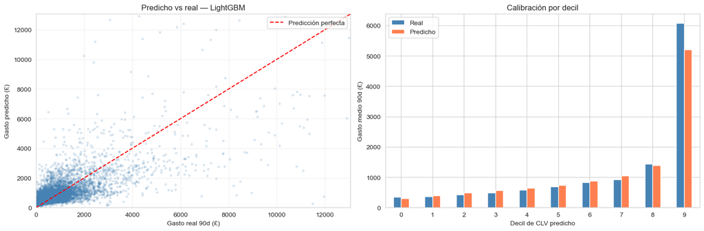

```
Decil superior: £6,075 de gasto real medio, 17x el decil inferior.
Para priorizar no hace falta acertar el gasto exacto, sino ordenar bien por valor.
```

```python
fig, axes = plt.subplots(1, 2, figsize=(15, 5))

lim = np.percentile(y_test, 99)
axes[0].scatter(y_test, y_pred_best, alpha=0.15, s=8, color='steelblue')
axes[0].plot([0, lim], [0, lim], ls='--', color='red', label='Predicción perfecta')
axes[0].set(xlim=(0, lim), ylim=(0, lim), xlabel='Gasto real 90d (£)',
            ylabel='Gasto predicho (£)', title=f'Predicho vs real — {NAMES[BEST_KEY]}')
axes[0].legend(); axes[0].grid(alpha=0.3)

comp = (pd.DataFrame({'decil': pd.qcut(y_pred_best, 10, labels=False, duplicates='drop'),
                      'Real': y_test.values, 'Predicho': y_pred_best})
        .groupby('decil')[['Real', 'Predicho']].mean())
comp.plot(kind='bar', ax=axes[1], color=['steelblue', 'coral'])
axes[1].set(xlabel='Decil de CLV predicho', ylabel='Gasto medio 90d (£)', title='Calibración por decil')
axes[1].tick_params(axis='x', rotation=0)

plt.tight_layout(); plt.show()

print(f"Decil superior: £{comp['Real'].iloc[-1]:,.0f} de gasto real medio, "
      f"{comp['Real'].iloc[-1]/comp['Real'].iloc[0]:.0f}x el decil inferior.")
print("Para priorizar no hace falta acertar el gasto exacto, sino ordenar bien por valor.")
```

## Importancia de variables

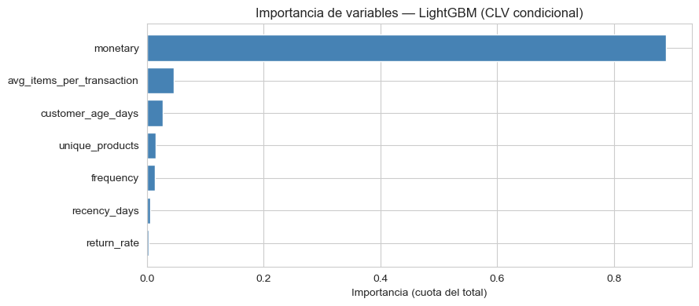

```
                  Feature  Importancia
                 monetary         88.9
avg_items_per_transaction          4.6
        customer_age_days          2.8
          unique_products          1.5
                frequency          1.3
             recency_days          0.6
              return_rate          0.3
```

```python
mejor = models[BEST_KEY]
if hasattr(mejor, 'booster_'):                 # LightGBM: ganancia (no recuento de cortes)
    imp = mejor.booster_.feature_importance(importance_type='gain').astype(float)
elif hasattr(mejor, 'get_booster'):            # XGBoost: ganancia
    score = mejor.get_booster().get_score(importance_type='gain')
    imp = np.array([score.get(f'f{i}', 0.0) for i in range(len(FEATURES))])
elif hasattr(mejor, 'feature_importances_'):   # Random Forest: reducción de impureza
    imp = mejor.feature_importances_.astype(float)
else:                                          # Ridge: |coeficiente|
    imp = np.abs(mejor.coef_)

importancia = pd.DataFrame({
    'Feature': FEATURES,
    'Importancia': imp / imp.sum(),            # cuota sobre el total, comparable entre modelos
}).sort_values('Importancia', ascending=False)

fig, ax = plt.subplots(figsize=(9, 4))
ax.barh(importancia['Feature'][::-1], importancia['Importancia'][::-1], color='steelblue')
ax.set(xlabel='Importancia (cuota del total)',
       title=f'Importancia de variables — {NAMES[BEST_KEY]} (CLV condicional)')
plt.tight_layout(); plt.show()

print(importancia.assign(Importancia=lambda d: (d['Importancia'] * 100).round(1)).to_string(index=False))
```

## Matriz de priorización: riesgo × valor

Aquí se encadenan las Preguntas 1 y 2 sobre **toda** la base de test (no sólo quienes volvieron: en producción no se sabe quién volverá).

- **Riesgo** = `P(churn)` del modelo de Fase 3, cortado por su umbral (no por un 0,5 arbitrario).
- **Valor** = CLV condicional de este notebook, cortado por su mediana.

La prioridad de un cuadrante no la da su **valor total en riesgo** sino su **valor en riesgo por contacto**: el presupuesto de una campaña se gasta por contacto, no por libra. Un cuadrante con el doble de población puede acumular un total parecido y aun así costar el doble por libra protegida. La tabla incluye ambas columnas para que la comparación sea explícita.

**Unidad.** Cada fila es una observación **cliente-ventana**, no un cliente: la decisión de retención se toma sobre un cliente *en un momento dado*, y el mismo cliente puede caer en cuadrantes distintos en meses distintos. La tabla informa de ambos recuentos para no repetir el doble conteo que se corrigió en el revenue por segmento.

```python
X_all = test_all[FEATURES]
churn_model = fase3[f"{fase3['best_model_key']}_best"]

matriz = test_all[['CustomerID', 'observation_date', 'future_monetary_90d']].copy()
matriz['churn_risk'] = churn_model.predict_proba(fase3['scaler'].transform(preprocess(X_all)))[:, 1]
matriz['clv_si_vuelve'] = predecir(BEST_KEY, scaler.transform(preprocess(X_all)))
matriz['valor_esperado'] = (1 - matriz['churn_risk']) * matriz['clv_si_vuelve']
matriz['valor_en_riesgo'] = matriz['churn_risk'] * matriz['clv_si_vuelve']

clv_median = matriz['clv_si_vuelve'].median()
alto_riesgo = matriz['churn_risk'] >= CHURN_THRESHOLD
alto_valor = matriz['clv_si_vuelve'] >= clv_median

matriz['prioridad'] = np.select(
    [alto_riesgo & alto_valor, ~alto_riesgo & alto_valor, alto_riesgo & ~alto_valor],
    ['1 · RETENER — alto riesgo, alto valor',
     '2 · FIDELIZAR — bajo riesgo, alto valor',
     '3 · DEJAR IR — alto riesgo, bajo valor'],
    default='4 · MONITOREAR — bajo riesgo, bajo valor')

CORR_RIESGO_VALOR = matriz.churn_risk.corr(matriz.clv_si_vuelve)

print(f"Corte de riesgo  P(churn) >= {CHURN_THRESHOLD:.3f} (umbral de Fase 3)")
print(f"Corte de valor   CLV si vuelve >= £{clv_median:,.0f} (mediana)")
print(f"Correlación riesgo-valor: {CORR_RIESGO_VALOR:.3f}\n")

# La unidad es la OBSERVACIÓN cliente-ventana, no el cliente: un mismo cliente aparece en
# varias ventanas del test y puede cambiar de cuadrante entre ellas. Llamarlas «clientes»
# sería incurrir en el mismo doble conteo que se corrigió en el revenue por segmento.
resumen = matriz.groupby('prioridad').agg(
    observaciones=('CustomerID', 'size'),
    clientes_distintos=('CustomerID', 'nunique'),
    riesgo_medio=('churn_risk', 'mean'),
    clv_medio=('clv_si_vuelve', 'mean'),
    valor_en_riesgo=('valor_en_riesgo', 'sum'),
    gasto_real_90d=('future_monetary_90d', 'sum'),
).round(2)
resumen['% valor en riesgo'] = (resumen.valor_en_riesgo / resumen.valor_en_riesgo.sum() * 100).round(1)
resumen['£ en riesgo/obs'] = (resumen.valor_en_riesgo / resumen.observaciones).round(0)
print(resumen.to_string())
# La columna `clientes_distintos` NO es una partición y no se suma: se calcula por
# cuadrante de forma independiente. Se publica el desglose del solape para que nadie
# sume la columna creyendo que censa la base.
n_cuad = matriz.groupby('CustomerID')['prioridad'].nunique()
reparto = n_cuad.value_counts().sort_index()
print(f"\nClientes distintos por cuadrante: NO sumables. El test tiene "
      f"{matriz.CustomerID.nunique():,} clientes únicos y {(n_cuad > 1).sum():,} de ellos "
      f"aparecen en más de un cuadrante según el mes "
      f"({', '.join(f'{v:,} en {k}' for k, v in reparto.items() if k > 1)}).")
print(f"  Por eso la columna suma {resumen.clientes_distintos.sum():,}, "
      f"que no es el censo del test sino la suma de cuatro recuentos con solape.")

# Total de valor ESPERADO en riesgo. Se publica explícitamente para poder contrastarlo
# con el valor REALMENTE perdido (03_Modeling, celda 15): son magnitudes distintas
# —una predicha sobre toda la base, otra observada sobre quien abandonó— y confundirlas
# fue un error de una versión anterior de este análisis.
print(f"\nValor esperado en riesgo, total: £{resumen.valor_en_riesgo.sum():,.0f} "
      f"(suma de los cuatro cuadrantes; riesgo predicho x CLV predicho sobre las "
      f"{len(matriz):,} observaciones del test).")

q1 = resumen.loc['1 · RETENER — alto riesgo, alto valor']
q3 = resumen.loc['3 · DEJAR IR — alto riesgo, bajo valor']
print(f"\nLectura: DEJAR IR acumula un total comparable a RETENER "
      f"(£{q3.valor_en_riesgo:,.0f} vs £{q1.valor_en_riesgo:,.0f}) pero repartido entre "
      f"{q3.observaciones/q1.observaciones:.1f}x más contactos.")
print(f"Por contacto, RETENER protege £{q1['£ en riesgo/obs']:,.0f} frente a "
      f"£{q3['£ en riesgo/obs']:,.0f} — {q1['£ en riesgo/obs']/q3['£ en riesgo/obs']:.1f}x más "
      f"por cada libra de campaña. Ahí está la prioridad, no en el total.")
```

```
Corte de riesgo  P(churn) >= 0.375 (umbral de Fase 3)
Corte de valor   CLV si vuelve >= £574 (mediana)
Correlación riesgo-valor: -0.345

                                          observaciones  clientes_distintos  riesgo_medio  clv_medio  valor_en_riesgo  gasto_real_90d  % valor en riesgo  £ en riesgo/obs
prioridad
1 · RETENER — alto riesgo, alto valor              5105                1991          0.57     891.73       2630183.52      2070885.19               44.2            515.0
2 · FIDELIZAR — bajo riesgo, alto valor            3605                1012          0.20    2071.20       1003937.19      7445093.27               16.9            278.0
3 · DEJAR IR — alto riesgo, bajo valor             8263                2563          0.67     415.01       2262520.78      1178894.84               38.0            274.0
4 · MONITOREAR — bajo riesgo, bajo valor            446                 202          0.29     461.17         58311.66       153283.67                1.0            131.0

Clientes distintos por cuadrante: NO sumables. El test tiene 4,128 clientes únicos y 1,404 de ellos aparecen en más de un cuadrante según el mes (1,183 en 2, 206 en 3, 15 en 4).
  Por eso la columna suma 5,768, que no es el censo del test sino la suma de cuatro recuentos con solape.

Valor esperado en riesgo, total: £5,954,953 (suma de los cuatro cuadrantes; riesgo predicho x CLV predicho sobre las 17,419 observaciones del test).

Lectura: DEJAR IR acumula un total comparable a RETENER (£2,262,521 vs £2,630,184) pero repartido entre 1.6x más contactos.
Por contacto, RETENER protege £515 frente a £274 — 1.9x más por cada libra de campaña. Ahí está la prioridad, no en el total.
```

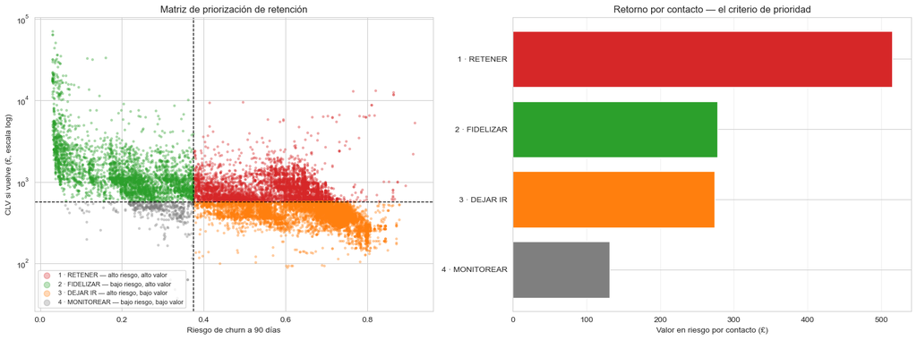

```
Cuadrante RETENER: 5,105 observaciones cliente-ventana (29% de la base), 1,991 clientes distintos.
  £2,630,184 de valor esperado en riesgo a 90 días.
  De ellos, 2,647 no volvieron a comprar (52%); los que sí volvieron gastaron £2,070,885.
```

```python
fig, axes = plt.subplots(1, 2, figsize=(16, 6))
colores = {'1 · RETENER — alto riesgo, alto valor': '#d62728',
           '2 · FIDELIZAR — bajo riesgo, alto valor': '#2ca02c',
           '3 · DEJAR IR — alto riesgo, bajo valor': '#ff7f0e',
           '4 · MONITOREAR — bajo riesgo, bajo valor': '#7f7f7f'}
for etiqueta, grupo in matriz.groupby('prioridad'):
    axes[0].scatter(grupo['churn_risk'], grupo['clv_si_vuelve'], s=6, alpha=0.3,
                    label=etiqueta, color=colores[etiqueta])
axes[0].axvline(CHURN_THRESHOLD, color='black', ls='--', lw=1)
axes[0].axhline(clv_median, color='black', ls='--', lw=1)
axes[0].set(yscale='log', xlabel='Riesgo de churn a 90 días',
            ylabel='CLV si vuelve (£, escala log)', title='Matriz de priorización de retención')
axes[0].legend(markerscale=3, loc='lower left', fontsize=8)

orden_q = resumen.sort_index()
etiquetas = [p.split('—')[0].strip() for p in orden_q.index]
axes[1].barh(etiquetas[::-1], orden_q['£ en riesgo/obs'][::-1],
             color=[colores[p] for p in orden_q.index][::-1])
axes[1].set(xlabel='Valor en riesgo por contacto (£)',
            title='Retorno por contacto — el criterio de prioridad')
axes[1].grid(alpha=0.3, axis='x')

plt.tight_layout(); plt.show()

top = matriz[matriz.prioridad.str.startswith('1')]
print(f"Cuadrante RETENER: {len(top):,} observaciones cliente-ventana "
      f"({len(top)/len(matriz):.0%} de la base), {top.CustomerID.nunique():,} clientes distintos.")
print(f"  £{top.valor_en_riesgo.sum():,.0f} de valor esperado en riesgo a 90 días.")
print(f"  De ellos, {(top.future_monetary_90d == 0).sum():,} no volvieron a comprar "
      f"({(top.future_monetary_90d == 0).mean():.0%}); los que sí volvieron gastaron "
      f"£{top.loc[top.future_monetary_90d > 0, 'future_monetary_90d'].sum():,.0f}.")
```

## Guardar

```python
with open('../models/models_clv.pkl', 'wb') as f:
    pickle.dump({
        **{f'{k}_best': m for k, m in models.items()},
        'scaler_clv': scaler, 'feature_columns': FEATURES, 'log_features': LOG_FEATURES,
        'best_model_key': BEST_KEY, 'gasto_max_train': gasto_max_train,
        'smearing': smearing[BEST_KEY], 'clv_median': clv_median,
        'model_names': NAMES, 'corr_riesgo_valor': CORR_RIESGO_VALOR,
        'cv_scores': {k: -g.best_score_ for k, g in grids.items()},
    }, f)

comparacion.to_csv('../outputs/fase3b_clv/clv_model_comparison.csv')
importancia.to_csv('../outputs/fase3b_clv/feature_importance_clv.csv', index=False)
matriz.to_csv('../outputs/fase3b_clv/churn_clv_priority_matrix.csv', index=False)
resumen.to_csv('../outputs/fase3b_clv/priority_quadrants_fase3b.csv')

for f in ['../models/models_clv.pkl', '../outputs/fase3b_clv/clv_model_comparison.csv', '../outputs/fase3b_clv/feature_importance_clv.csv',
          '../outputs/fase3b_clv/churn_clv_priority_matrix.csv', '../outputs/fase3b_clv/priority_quadrants_fase3b.csv']:
    print(f)
```

```
../models/models_clv.pkl
../outputs/fase3b_clv/clv_model_comparison.csv
../outputs/fase3b_clv/feature_importance_clv.csv
../outputs/fase3b_clv/churn_clv_priority_matrix.csv
../outputs/fase3b_clv/priority_quadrants_fase3b.csv
```